# 高级R第二版-函数式编程

Studennt. LI Junjie

Dongbei University of Finance & Economics

2020-08-05

# 加载经常用的R包

```r
library(pacman)
# 读数据
p_load(readxl,writexl,data.table,openxlsx,haven,rvest)
```

```r
# 数据探索
p_load(tidyverse,DT,skimr,DataExplorer,explore,vtable,stringr,kableExtra,lubridate)
```

```r
# 模型
p_load(grf,glmnet,caret,tidytext,fpp2,forecast,car,tseries,hdm,tidymodels,broom)
```

```r
# 可视化
p_load(patchwork,ggrepel,ggcorrplot,gghighlight,ggthemes,shiny)
```

```r
# 其它常用包
p_load(magrittr,listviewer,devtools,here,janitor,reticulate,jsonlite)
```

# 介绍

R本质上是函数型语言。这意味着它具有某些技术特性，但更重要的是，它适合于以功能为中心的问题解决方式。下面，我将简要概述函数式语言的技术定义，但是在本书中，我将主要侧重于编程的函数式风格，因为我认为它非常适合您通常遇到的问题类型做数据分析。

最近，函数技术引起了人们的关注，因为它们可以为许多现代问题提供有效而优雅的解决方案。函数样式倾向于创建可以轻松地独立分析（即仅使用本地信息）的函数，因此通常更容易自动优化或并行化。近年来，函数式语言的传统弱点，较差的性能以及有时无法预测的内存使用情况已得到大大减轻。函数式编程是对面向对象编程的补充，后者在过去的几十年中一直是占主导地位的编程范例。

每种编程语言都有函数，那么什么使编程语言起作用呢？ 关于使语言起作用的确切定义有很多，但是有两个共同的线程。

首先，函数语言具有一流的功能，这些功能的行为类似于任何其他数据结构。在R中，这意味着您可以使用可以使用向量执行的函数来完成许多事情：可以将它们分配给变量，将它们存储在列表中，将它们作为参数传递给其他函数，在函数内部创建它们，以及甚至将它们作为函数的结果返回。

其次，许多函数式语言要求功能是纯净的。 如果一个函数满足两个属性，则该函数是纯函数：

- 输出仅取决于输入，即，如果再次使用相同的输入调用它，则将获得相同的输出。这不包括诸如`runif（）`，`read.csv（）`或`Sys.time（）`之类的可以返回不同值的函数。
- 该函数没有副作用，例如更改全局变量的值，写入磁盘或显示在屏幕上。这不包括`print（）`，`write.csv（）`和`<-`之类的函数。

纯函数更容易推理，但显然也有明显的缺点: 想象一下，在不能生成随机数或从磁盘读取文件的情况下进行数据分析。

严格来说，**R不是函数式编程语言**，因为它不需要您编写纯函数。但是，您当然可以在部分代码中采用函数样式：您不必编写纯函数，但通常应该这样做。以我的经验，将代码划分为极纯或极不纯净的函数往往会导致代码更易于理解并扩展到新的情况。

很难准确地描述**函数式风格是什么**，但是通常我认为它意味着将**一个大问题分解成更小的部分**，然后用一个函数或者函数组合来解决每个部分。在使用函数样式时，您要努力将问题的组件分解为独立运行的独立函数。每个函数本身都是简单易懂的; 复杂性通过以各种方式组合函数来处理。

# 1 函数

## 1.1 介绍

一个函数是一个函数，它接受一个函数作为输入，并返回一个向量作为输出。这里有一个简单的函数: 它**用1000个随机均匀数调用作为输入提供的函数**。

```r
set.seed(123)
randomise <- function(f){
  f(runif(1000))
}

randomise(mean)
```

```
## [1] 0.4972778
```

如果你是一个经验丰富的for循环用户，切换到函数通常是一个模式匹配的练习。查看for循环并找到与基本形式匹配的函数。如果一个不存在，不要试图折磨一个现有的函数来适应你需要的形式。相反，只要把它作为for循环就可以了！(或者一旦你重复同一个循环两次或更多次，也许考虑编写你自己的函数)。

## 1.2 map函数

最基本的函数是`purrr::map（）`。它需要一个向量和一个函数，对向量的每个元素调用一次函数，然后将结果返回到列表中。换句话说，`map（1:3，f）`等同于`list（f（1），f（2），f（3））`。

```r
triple <- function(x){
  return(x*3)
}
map(1:3,triple)
```

```
## [[1]]
## [1] 3
##
## [[2]]
## [1] 6
##
## [[3]]
## [1] 9
```

```r
map(1:3,function(j){
  map_dbl(1:3,function(i){
  x <- i + j
  return((x))
})
})
```

```
## [[1]]
## [1] 2 3 4
##
## [[2]]
## [1] 3 4 5
##
## [[3]]
## [1] 4 5 6
```

```r
map(1:3,function(j){
  map(1:3,function(i){
  x <- i + j
  return((x))
})
}) %>% listviewer::jsonedit()
```

[interactive chart not shown]

### 1.2.1 Producing atomic vectors

`Map()`返回一个 list，这使它成为map族中最通用的，因为您可以将任何内容放入一个list中。但是，如果使用更简单的数据结构，返回一个列表是不方便的，因此有四个更具体的变量:`map_lgl()`、`map_int()`、`map_dbl()`和`map_chr()`。每个函数返回一个指定类型的原子向量:

```r
map_chr(mtcars,typeof)
```

```
##      mpg      cyl     disp       hp     drat       wt     qsec       vs
## "double" "double" "double" "double" "double" "double" "double" "double"
##       am     gear     carb
## "double" "double" "double"
```

```r
map_lgl(mtcars,is.double)
```

```
##  mpg  cyl disp   hp drat   wt qsec   vs   am gear carb
## TRUE TRUE TRUE TRUE TRUE TRUE TRUE TRUE TRUE TRUE TRUE
```

```r
map_int(mtcars,n_distinct)
```

```
##  mpg  cyl disp   hp drat   wt qsec   vs   am gear carb
##   25    3   27   22   22   29   30    2    2    3    6
```

```r
map_dbl(mtcars, mean)
```

```
##        mpg        cyl       disp         hp       drat         wt       qsec
##  20.090625   6.187500 230.721875 146.687500   3.596563   3.217250  17.848750
##         vs         am       gear       carb
##   0.437500   0.406250   3.687500   2.812500
```

`purrr`使用后缀（如`_dbl（）`）引用输出的约定。所有`map_*（）`函数都可以采用任何类型的向量作为输入。这些示例基于两个事实：`mtcars`是一个数据帧，而数据帧是包含相同长度向量的列表。

所有映射函数**始终返回与输入长度相同的输出向量**，这意味着对.f的每次调用都必须返回单个值。如果没有，您将得到一个错误：

```r
map(1:2,as.character)
```

```
## [[1]]
## [1] "1"
##
## [[2]]
## [1] "2"
```

```r
map_dbl(1:2,as.character)
```

```
## Error: Can't coerce element 1 from a character to a double
```

```r
pair <- function(x) c(x, x)
map(1:2,pair)
```

```
## [[1]]
## [1] 1 1
##
## [[2]]
## [1] 2 2
```

```r
map_dbl(1:2,pair)
```

```
## Error: Result 1 must be a single double, not an integer vector of length 2
```

无论哪种情况，切换回`map（）`都是很有用的，因为`map（）`可以接受任何类型的输出。这样您就可以查看有问题的输出，并弄清楚该如何处理。

```r
map(1:2,pair)
```

```
## [[1]]
## [1] 1 1
##
## [[2]]
## [1] 2 2
```

```r
map(1:2,as.character)
```

```
## [[1]]
## [1] "1"
##
## [[2]]
## [1] "2"
```

`Base R`有两个可以返回原子向量的apply函数：`sapply（）`和`vapply（）`。我建议您避免使用sapply（），因为它会尝试简化结果，因此它可以返回列表，向量或矩阵。这使编程变得很困难，在非交互式设置中应避免编程。`vapply（）`更安全，因为它允许您提供描述输出形状的模板FUN.VALUE。如果您不想使用`purrr`，建议您始终在函数中使用`vapply（）`，而不要在`sapply（）`中使用。 **vapply（）的主要缺点**是它的详细程度：例如，与`map_dbl（x，mean，na.rm = TRUE）`等效的是`vapply（x，mean，na.rm = TRUE，FUN.VALUE = double（1））`。

### 1.2.2 Anonymous functions and shortcuts

您可以创建内联匿名函数，而不是将`map（）`与现有函数一起使用：

```r
map(mtcars,~n_distinct(.x)) %>% unlist()
```

```
##  mpg  cyl disp   hp drat   wt qsec   vs   am gear carb
##   25    3   27   22   22   29   30    2    2    3    6
```

```r
map(mtcars,function(i){
  n_distinct(i)
}) %>% bind_cols()
```

| mpg | cyl | disp | hp | drat | wt | qsec | vs | am | gear | carb |
| --- | --- | --- | --- | --- | --- | --- | --- | --- | --- | --- |
| 25 | 3 | 27 | 22 | 22 | 29 | 30 | 2 | 2 | 3 | 6 |

```r
map(1:3,~runif(2))
```

```
## [[1]]
## [1] 0.2736227 0.5938669
##
## [[2]]
## [1] 0.1601848 0.8534302
##
## [[3]]
## [1] 0.8477392 0.4778868
```

```r
x <- list(
  list(-1, x = 1, y = c(2), z = "a"),
  list(-2, x = 4, y = c(5, 6), z = "b"),
  list(-3, x = 8, y = c(9, 10, 11))
)
x
```

```
## [[1]]
## [[1]][[1]]
## [1] -1
##
## [[1]]$x
## [1] 1
##
## [[1]]$y
## [1] 2
##
## [[1]]$z
## [1] "a"
##
##
## [[2]]
## [[2]][[1]]
## [1] -2
##
## [[2]]$x
## [1] 4
##
## [[2]]$y
## [1] 5 6
##
## [[2]]$z
## [1] "b"
##
##
## [[3]]
## [[3]][[1]]
## [1] -3
##
## [[3]]$x
## [1] 8
##
## [[3]]$y
## [1]  9 10 11
```

```r
map_dbl(x,"x")
```

```
## [1] 1 4 8
```

```r
map_dbl(x,1)
```

```
## [1] -1 -2 -3
```

```r
map_dbl(x,list("y",1))
```

```
## [1] 2 5 9
```

```r
map_chr(x,"z")
```

```
## Error: Result 3 must be a single string, not NULL of length 0
```

```r
# Unless you supply a .default value
map_chr(x, "z", .default = NA)
```

```
## [1] "a" "b" NA
```

### 1.2.3 Passing arguments with …

将附加参数传递给要调用的函数通常很方便。例如，您可能希望将`na.rm = TRUE`传递给`mean`()。一种方法是使用一个匿名函数:

```r
x <- list(1:5,c(1:10,NA))
map_dbl(x,~mean(.x,na.rm = TRUE))
```

```
## [1] 3.0 5.5
```

```r
map(x,~mean(.x,na.rm = TRUE))
```

```
## [[1]]
## [1] 3
##
## [[2]]
## [1] 5.5
```

```r
map(x,function(i){
  mean(i,na.rm = TRUE)
})
```

```
## [[1]]
## [1] 3
##
## [[2]]
## [1] 5.5
```

请注意，在**匿名函数**中放置额外的参数与将它们传递给`map()`之间有细微的差别。将它们放在匿名函数中意味着每次执行`f()`时都会计算它们，而不仅仅是在调用`map()`时计算一次。这是最容易看到的，如果我们使附加的论点随机:

```r
plus <- function(x,y){
  x + y
}

x <- c(0,0,0,0)

map(x,plus,runif(1))
```

```
## [[1]]
## [1] 0.7736921
##
## [[2]]
## [1] 0.7736921
##
## [[3]]
## [1] 0.7736921
##
## [[4]]
## [1] 0.7736921
```

```r
map(x,~plus(.x,runif(1)))
```

```
## [[1]]
## [1] 0.2954001
##
## [[2]]
## [1] 0.06562811
##
## [[3]]
## [1] 0.4405331
##
## [[4]]
## [1] 0.4620989
```

```r
map(1:3,function(x){
  x + runif(1)
})
```

```
## [[1]]
## [1] 1.340934
##
## [[2]]
## [1] 2.18514
##
## [[3]]
## [1] 3.506998
```

### 1.2.4 Argument names

这就是`map()`的参数有点奇怪的原因: 它们不是 `x` 和 `f`，而是。`.x` 和`.f`。使用上面定义的`simple_map()`可以很容易地看到导致这些名称的问题。Simple_map()有参数x和f，**所以只要你调用的函数有参数 x 或者 f，你就会遇到问题:**

```r
map(1:3,function(i){
  i + runif(1)
})
```

```
## [[1]]
## [1] 1.019191
##
## [[2]]
## [1] 2.773686
##
## [[3]]
## [1] 3.559665
```

```r
boostrap_summary <- function(x, f) {
  f(sample(x, replace = TRUE))
}
simple_map <- function(x, f, ...) {
  out <- vector("list", length(x))
  for (i in seq_along(x)) {
    out[[i]] <- f(x[[i]], ...)
  }
  out
}

simple_map(mtcars, boostrap_summary, f = mean)
```

```
## Error in mean.default(x[[i]], ...): 'trim' must be numeric of length one
```

```r
map(mtcars,~ boostrap_summary(.x,f = mean))
```

```
## $mpg
## [1] 22.15625
##
## $cyl
## [1] 6.0625
##
## $disp
## [1] 226.8063
##
## $hp
## [1] 151.3438
##
## $drat
## [1] 3.604062
##
## $wt
## [1] 3.154125
##
## $qsec
## [1] 17.74312
##
## $vs
## [1] 0.375
##
## $am
## [1] 0.4375
##
## $gear
## [1] 3.5625
##
## $carb
## [1] 3.15625
```

### 1.2.5 Varying another argument

```r
map(c(0,0.2,0.4,0.6,0.8),function(i){
  mean(rcauchy(10000),trim = i)
})
```

```
## [[1]]
## [1] 0.9328207
##
## [[2]]
## [1] 0.03289042
##
## [[3]]
## [1] 0.009352752
##
## [[4]]
## [1] 0.02568928
##
## [[5]]
## [1] 0.01602803
```

```r
map_dbl(c(0,0.1,0.2),function(trim){
  mean(rcauchy(10000),trim = trim)
})
```

```
## [1] -0.763733485  0.017277810 -0.001368966
```

**练习**

```r
as_mapper(map_int)
```

```
## function (.x, .f, ...)
## {
##     .f <- as_mapper(.f, ...)
##     .Call(map_impl, environment(), ".x", ".f", "integer")
## }
## <bytecode: 0x000000002be67390>
## <environment: namespace:purrr>
```

`Map(1:3，~ runif (2))`是生成随机数的有用模式，但`map(1:3，runif(2))`不是。为什么不呢？你能解释一下为什么它返回的结果是这样的吗？

```r
map(1:3,function(i){
  runif(2)
})
```

```
## [[1]]
## [1] 0.5595670 0.9011365
##
## [[2]]
## [1] 0.56544814 0.02526871
##
## [[3]]
## [1] 0.4081247 0.3718472
```

```r
map(1:3,runif(2))
```

[output not shown]

```r
map(mpg,typeof) %>% unlist()
```

```
## manufacturer        model        displ         year          cyl        trans
##  "character"  "character"     "double"    "integer"    "integer"  "character"
##          drv          cty          hwy           fl        class
##  "character"    "integer"    "integer"  "character"  "character"
```

```r
map(mpg %>% select(where(is.numeric)),~sd(.x))
```

```
## $displ
## [1] 1.291959
##
## $year
## [1] 4.509646
##
## $cyl
## [1] 1.611534
##
## $cty
## [1] 4.255946
##
## $hwy
## [1] 5.954643
```

```r
map(iris %>% select(where(is.factor)),~n_distinct(.x))
```

```
## $Species
## [1] 3
```

```r
trials <- map(1:100, ~ t.test(rpois(10, 10), rpois(7, 10)))
trials[[1]]$p.value
```

```
## [1] 0.03824384
```

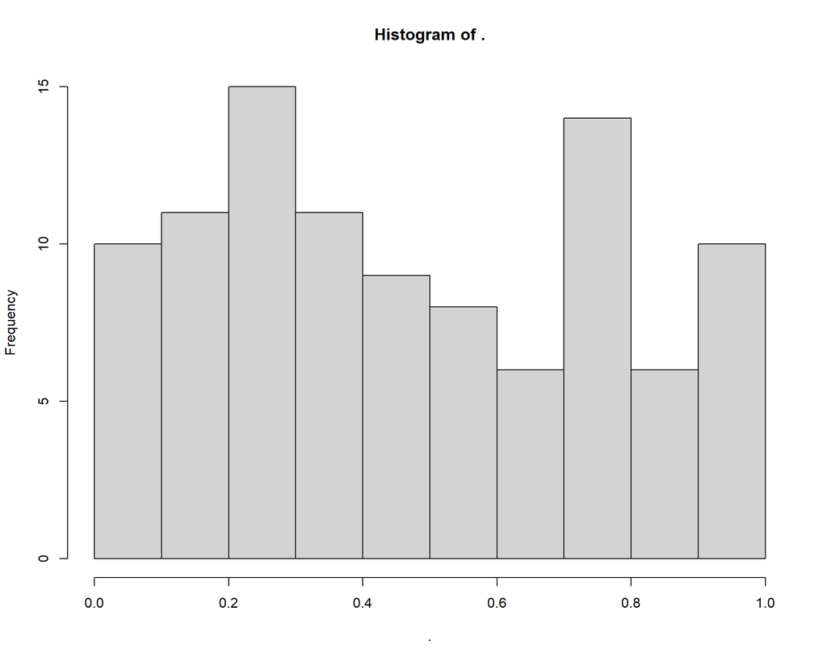

```r
map(trials,"p.value") %>% unlist() %>% hist()
```

```r
x <- list(
  list(1, c(3, 9)),
  list(c(3, 6), 7, c(4, 7, 6))
)

triple <- function(x) x * 3
# x[[1]] %>% map(triple)

map(seq_along(x),function(i){
  x[[i]] %>% map(triple)
})
```

```
## [[1]]
## [[1]][[1]]
## [1] 3
##
## [[1]][[2]]
## [1]  9 27
##
##
## [[2]]
## [[2]][[1]]
## [1]  9 18
##
## [[2]][[2]]
## [1] 21
##
## [[2]][[3]]
## [1] 12 21 18
```

```r
formulas <- list(
  mpg ~ disp,
  mpg ~ I(1 / disp),
  mpg ~ disp + wt,
  mpg ~ I(1 / disp) + wt
)
map(formulas,~lm(formula = .x,data = mtcars))
```

```
## [[1]]
##
## Call:
## lm(formula = .x, data = mtcars)
##
## Coefficients:
## (Intercept)         disp
##    29.59985     -0.04122
##
##
## [[2]]
##
## Call:
## lm(formula = .x, data = mtcars)
##
## Coefficients:
## (Intercept)    I(1/disp)
##       10.75      1557.67
##
##
## [[3]]
##
## Call:
## lm(formula = .x, data = mtcars)
##
## Coefficients:
## (Intercept)         disp           wt
##    34.96055     -0.01772     -3.35083
##
##
## [[4]]
##
## Call:
## lm(formula = .x, data = mtcars)
##
## Coefficients:
## (Intercept)    I(1/disp)           wt
##      19.024     1142.560       -1.798
```

```r
lm(formula = mpg ~ disp,data = mtcars)  # 当复制次数多，可以考虑map映射
```

```
##
## Call:
## lm(formula = mpg ~ disp, data = mtcars)
##
## Coefficients:
## (Intercept)         disp
##    29.59985     -0.04122
```

```r
sample(nrow(mtcars),replace = TRUE) %>% n_distinct()
```

```
## [1] 22
```

```r
mtcars[sample(nrow(mtcars),replace = TRUE),]
```

|  | mpg | cyl | disp | hp | drat | wt | qsec | vs | am | gear | carb |
| --- | --- | --- | --- | --- | --- | --- | --- | --- | --- | --- | --- |
| Ferrari Dino | 19.7 | 6 | 145.0 | 175 | 3.62 | 2.770 | 15.50 | 0 | 1 | 5 | 6 |
| Valiant | 18.1 | 6 | 225.0 | 105 | 2.76 | 3.460 | 20.22 | 1 | 0 | 3 | 1 |
| Chrysler Imperial | 14.7 | 8 | 440.0 | 230 | 3.23 | 5.345 | 17.42 | 0 | 0 | 3 | 4 |
| Chrysler Imperial.1 | 14.7 | 8 | 440.0 | 230 | 3.23 | 5.345 | 17.42 | 0 | 0 | 3 | 4 |
| Merc 280C | 17.8 | 6 | 167.6 | 123 | 3.92 | 3.440 | 18.90 | 1 | 0 | 4 | 4 |
| Hornet 4 Drive | 21.4 | 6 | 258.0 | 110 | 3.08 | 3.215 | 19.44 | 1 | 0 | 3 | 1 |
| Ford Pantera L | 15.8 | 8 | 351.0 | 264 | 4.22 | 3.170 | 14.50 | 0 | 1 | 5 | 4 |
| Fiat 128 | 32.4 | 4 | 78.7 | 66 | 4.08 | 2.200 | 19.47 | 1 | 1 | 4 | 1 |
| Mazda RX4 | 21.0 | 6 | 160.0 | 110 | 3.90 | 2.620 | 16.46 | 0 | 1 | 4 | 4 |
| Valiant.1 | 18.1 | 6 | 225.0 | 105 | 2.76 | 3.460 | 20.22 | 1 | 0 | 3 | 1 |

[output cut: 22 more lines]

```r
bootstrap <- function(df) {
  df[sample(nrow(df), replace = TRUE), , drop = FALSE]
}

bootstraps <- map(1:10, ~ bootstrap(mtcars))
map(bootstraps,~lm(formula = mpg ~ disp,data = .x)) %>%
  map(summary) %>%
  map("r.squared")
```

```
## [[1]]
## [1] 0.6833492
##
## [[2]]
## [1] 0.6970878
##
## [[3]]
## [1] 0.7104124
##
## [[4]]
## [1] 0.7634015
##
## [[5]]
## [1] 0.7250579
##
## [[6]]
## [1] 0.8378598
##
## [[7]]
## [1] 0.7150484
##
## [[8]]
## [1] 0.7725958
##
## [[9]]
## [1] 0.6901548
##
## [[10]]
## [1] 0.7572713
```

**总结**：map函数处理列表很容易，如果是嵌套列表，可以直接通过列名和位置提取元素

```r
map(list(list(x = 1:10)),1)
```

```
## [[1]]
##  [1]  1  2  3  4  5  6  7  8  9 10
```

```r
map(list(list(x = 1:10)),"x")
```

```
## [[1]]
##  [1]  1  2  3  4  5  6  7  8  9 10
```

```r
mtcars %>%
  split(mtcars$cyl) %>%
  map(.,~lm(mpg ~ wt,data = .x)) %>%
  map(.,summary) %>%
  map("r.squared")
```

```
## $`4`
## [1] 0.5086326
##
## $`6`
## [1] 0.4645102
##
## $`8`
## [1] 0.4229655
```

## 1.3 Purrr style

```r
by_cyl <- split(mtcars, mtcars$cyl)
by_cyl %>%
  map(~ lm(mpg ~ wt,data = .x)) %>%
  map("coefficients") %>%
  map(2) %>% unlist()
```

```
##         4         6         8
## -5.647025 -2.780106 -2.192438
```

我认为这个代码很容易阅读，因为每一行都封装了一个单独的步骤，你可以很容易地区分函数和它所做的事情，`purrr helpers`允许我们非常简洁地描述在每一个步骤中要做什么。

有趣的是，当您从 `purrr` 移动到 `base apply`函数再移动到`for`循环时，您在每次迭代中所做的工作往往越来越多。在 purrr 中，我们迭代3次(`map()`、`map()`、`map_dbl()`)，对于apply函数，我们迭代两次(`lapply()`、`vapply()`)，对于for循环，我们迭代一次。我更喜欢更多但更简单的步骤，因为我认为它使代码更容易理解和以后修改。

## 1.4 Map变体

`Map()`有23个主要变体。到目前为止，您已经学习了5个(`map()`、 `map_lgl ()`、 `map_int()`、`map_dbl()`和`map_chr()`)。这意味着你得了18分还有很多东西要学。这听起来很多，但幸运的是purrr的设计意味着你只需要学习5个新的想法:

- Output same type as input with `modify()`
- Iterate over two inputs with `map2()`.
- Iterate with an index using `imap()`
- Return nothing with `walk()`.
- Iterate over any number of inputs with `pmap()`.

### 1.4.1 Same type of output as input: `modify()`

```r
df <- data.frame(
  x = 1:3,
  y = 6:4
)
map(df,~.x * 2) %>% bind_rows()
```

| x | y |
| --- | --- |
| 2 | 12 |
| 4 | 10 |
| 6 | 8 |

```r
modify(df,~.x * 2)
```

| x | y |
| --- | --- |
| 2 | 12 |
| 4 | 10 |
| 6 | 8 |

### 1.4.2 Two inputs: `map2()` and friends

```r
xs <- map(1:8, ~ runif(10))
xs
```

```
## [[1]]
##  [1] 0.43447100 0.32049581 0.29527062 0.99105321 0.54115140 0.69913310
##  [7] 0.93023074 0.81311962 0.06192224 0.90856216
##
## [[2]]
##  [1] 0.04980037 0.54250549 0.08370869 0.31194225 0.27454372 0.30739147
##  [7] 0.78674962 0.58056092 0.73078234 0.32910475
##
## [[3]]
##  [1] 0.5239598 0.5063902 0.5665278 0.1388185 0.5925049 0.1357565 0.7970982
##  [8] 0.7356329 0.2294704 0.8322150
##
## [[4]]
##  [1] 0.4931688 0.7095971 0.9726656 0.2942915 0.7060225 0.7844556 0.8524926
##  [8] 0.5727982 0.8990380 0.2918305
##
## [[5]]
##  [1] 0.18979686 0.14148877 0.23930440 0.99770188 0.07029058 0.26065489
##  [7] 0.33726984 0.24844151 0.96694151 0.79147564
##
## [[6]]
##  [1] 0.77787600 0.90938871 0.28265385 0.07482142 0.62860064 0.43535889
##  [7] 0.48251157 0.29265783 0.16139069 0.56868699
##
## [[7]]
##  [1] 0.33619338 0.28048163 0.24202700 0.93769943 0.08179959 0.87657485
##  [7] 0.29335453 0.82818334 0.54336664 0.41512711
##
## [[8]]
##  [1] 0.5767966 0.9560398 0.2249488 0.1663832 0.3589655 0.6102226 0.1544017
##  [8] 0.4595735 0.8361794 0.7792224
```

```r
xs[[1]][[1]] <- NA
```

```r
ws <- map(1:8, ~ rpois(10, 5) + 1)
ws
```

```
## [[1]]
##  [1] 7 5 6 2 7 4 9 7 6 7
##
## [[2]]
##  [1] 10  4  4  6  3  8 10  6  7  8
##
## [[3]]
##  [1]  2 11  7  5  6  5  4 10  2  4
##
## [[4]]
##  [1]  3  5 10  4  3  7 12  8  4  6
##
## [[5]]
##  [1]  8  3  6  7  5  4 11  3  3  6
##
## [[6]]
##  [1]  5  2  3  7  2  8 13  5  3  4
##
## [[7]]
##  [1]  8  6  6  6  5  2  3  4 10  5
##
## [[8]]
##  [1] 5 3 9 6 4 4 6 5 8 9
```

```r
map(xs,mean) %>% unlist()
```

```
## [1]        NA 0.3997090 0.5058374 0.6576360 0.4243366 0.4613947 0.4834808
## [8] 0.5122734
```

```r
map2(1:3,1:3,sum)
```

```
## [[1]]
## [1] 2
##
## [[2]]
## [1] 4
##
## [[3]]
## [1] 6
```

```r
map2(xs,ws,function(i,j){
  i * j
})
```

```
## [[1]]
##  [1]        NA 1.6024791 1.7716237 1.9821064 3.7880598 2.7965324 8.3720766
##  [8] 5.6918374 0.3715334 6.3599351
##
## [[2]]
##  [1] 0.4980037 2.1700220 0.3348348 1.8716535 0.8236312 2.4591318 7.8674962
##  [8] 3.4833655 5.1154764 2.6328380
##
## [[3]]
##  [1] 1.0479195 5.5702926 3.9656949 0.6940924 3.5550291 0.6787826 3.1883927
##  [8] 7.3563290 0.4589407 3.3288599
##
## [[4]]
##  [1]  1.479506  3.547985  9.726656  1.177166  2.118067  5.491189 10.229911
##  [8]  4.582385  3.596152  1.750983
##
## [[5]]
##  [1] 1.5183749 0.4244663 1.4358264 6.9839131 0.3514529 1.0426195 3.7099683
##  [8] 0.7453245 2.9008245 4.7488538
##
## [[6]]
##  [1] 3.8893800 1.8187774 0.8479615 0.5237500 1.2572013 3.4828711 6.2726504
##  [8] 1.4632892 0.4841721 2.2747480
##
## [[7]]
##  [1] 2.6895470 1.6828898 1.4521620 5.6261966 0.4089979 1.7531497 0.8800636
##  [8] 3.3127333 5.4336664 2.0756356
##
## [[8]]
##  [1] 2.8839831 2.8681194 2.0245394 0.9982989 1.4358619 2.4408904 0.9264103
##  [8] 2.2978676 6.6894355 7.0130013
```

```r
map2_dbl(xs, ws, weighted.mean, na.rm = TRUE)
```

```
## [1] 0.6176638 0.4129766 0.5329345 0.7048387 0.4261004 0.4291308 0.4602735
## [8] 0.5013289
```

```r
map2(list(x = 1:10),list(x = 1:10),sum)
```

```
## $x
## [1] 110
```

### 1.4.3 No outputs: `walk()` and friends

```r
welcome <- function(x) {
  cat("Welcome ", x, "!\n", sep = "")
}
names <- c("Hadley", "Jenny")
map(names,welcome)
```

```
## Welcome Hadley!
## Welcome Jenny!
```

```r
walk(names,welcome)
```

```
## Welcome Hadley!
## Welcome Jenny!
```

我对`walk`的可视化描述试图捕获`map ()`的重要区别: 输出是临时的，输入是不可见的返回。

[figure not shown]

`Walk2()`是最有用的`walk()`变体之一，因为一个非常常见的副作用是将某些内容保存到磁盘，并且当将某些内容保存到磁盘时，总是有一对值: 要将其保存到的对象和路径。

[figure not shown]

例如，假设您有一个数据帧列表(我在这里使用`split()`创建的)，您希望将每个数据帧保存到一个单独的 CSV 文件中。使用`walk2()`就很容易:

```r
# temp <- tempfile()
# dir.create("temp")
cyls <- split(mtcars, mtcars$cyl)
paths <- str_c("data/cyl-",names(cyls),".csv")
paths
map2(cyls,paths,write.csv)
walk2(cyls,paths,write_csv)
```

Here the `walk2()` is equivalent to `write.csv(cyls[[1]], paths[[1]])`, `write.csv(cyls[[2]], paths[[2]])`, `write.csv(cyls[[3]], paths[[3]])`.

### 1.4.4 Iterating over values and indices

`imap()` is like `map2()` in the sense that your .f gets called with two arguments, but here both are derived from the vector. `imap(x, f)` is equivalent to `map2(x, names(x), f)` if x has names, and `map2(x, seq_along(x), f)` if it does not.

### 1.4.5 Any number of inputs: `pmap()` and friends

因为我们有 `map()`和 `map2()` ，所以您可能期望看到 `map3()`、 `map4()`、 `map5()` ，… … 但是您会在哪里停止呢？`Purrr`没有将`map2()`泛化为任意数量的参数，而是使用`pmap()`采用了稍微不同的策略:您为它提供一个单一的列表，其中包含任意数量的参数。在大多数情况下，**这将是一个等长向量列表**，即与数据帧非常相似的内容。在图表中，我将通过类似于数据帧的方式来强调这种关系。

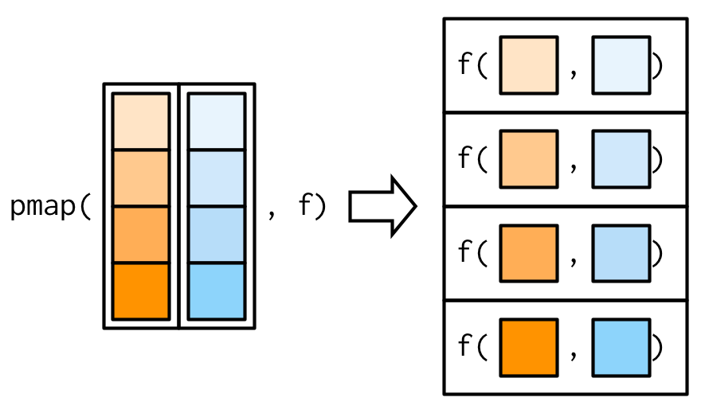

```r
pmap(list(x = 1:3, y = 1:3),sum)
```

```
## [[1]]
## [1] 2
##
## [[2]]
## [1] 4
##
## [[3]]
## [1] 6
```

```r
pmap(list(list(1:3),
          list(1:3)),
     sum)
```

```
## [[1]]
## [1] 12
```

`Map2()`和 `pmap()`之间有一个简单的等价关系: `map2(x，y，f)`与 `pmap(list (x，y) ，f)`相同。

```r
map2(1:3,1:3,sum)
```

```
## [[1]]
## [1] 2
##
## [[2]]
## [1] 4
##
## [[3]]
## [1] 6
```

```r
walk2(1:3,1:3,sum)
pmap(list(1:3,1:3),sum)
```

```
## [[1]]
## [1] 2
##
## [[2]]
## [1] 4
##
## [[3]]
## [1] 6
```

使用数据帧调用 `pmap ()`通常很方便。创建数据帧的一种简便方法是 `tibble::tribble ()`，它允许您逐行描述数据帧(而不是像往常一样逐列描述):将函数的参数看作数据帧是一种非常强大的模式。下面的例子展示了如何用不同的参数绘制随机均匀数:

```r
params <- tibble::tribble(
  ~ n, ~ min, ~ max,
   1L,     0,     1,
   2L,    10,   100,
   3L,   100,  1000
)
params %>% pmap(runif)
```

```
## [[1]]
## [1] 0.3644703
##
## [[2]]
## [1] 74.87131 20.63172
##
## [[3]]
## [1] 836.9610 218.5963 458.0690
```

```r
list(n = 1:3,min = c(0,10,100),max = c(1,100,1000)) %>% pmap(runif)
```

```
## [[1]]
## [1] 0.4319398
##
## [[2]]
## [1] 50.72129 47.83714
##
## [[3]]
## [1] 438.0068 285.5865 930.9233
```

```r
list(n = 1:3,min = c(0,10,100),max = c(1,100,1000)) -> x
runif(x[[1]][[1]],x[[2]][[1]],x[[3]][[1]])
```

```
## [1] 0.9732457
```

```r
runif(x[[1]][[2]],x[[2]][[2]],x[[3]][[2]])
```

```
## [1] 73.28353 92.14627
```

```r
runif(x[[1]][[3]],x[[2]][[3]],x[[3]][[3]])
```

```
## [1] 234.5750 206.8804 882.0601
```

```r
# 这就是pmap的核心
```

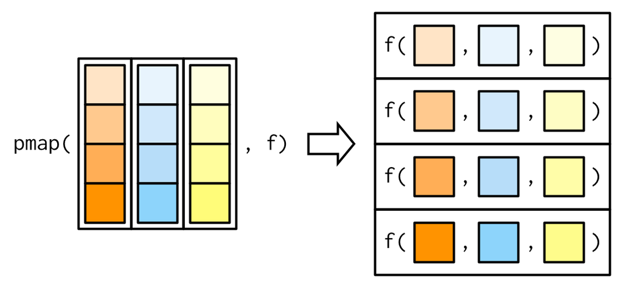

在这里，**列名是关键的**: 我仔细地选择它们与`runif()`的参数匹配，因此`pmap (params，runif)`等价于 `runif (n = 1L，min = 0，max = 1)` ，`runif (n = 2，min = 10，max = 100)` ，`runif(n=3L，min=100，max=1000)`。(如果您手头有一个数据帧，而且名称不匹配，请使用`dplyr::rename()`或类似的名称。)

在base R中，`Pmap()`家族有两个基本等价物:`Map()`和`mapply()`。这两种方法都有明显的缺点:`Map()`对所有参数进行向量化，因此不能提供不变的参数。`Mapply ()`是 `sapply ()`的多维版本; 从概念上讲，它接受`Map()`的输出，并尽可能简化它。这给了它与`sapply()`类似的问题。没有 `vapply()`的多输入等效项。

**练习**

```r
map(mtcars,1)
```

```
## $mpg
## [1] 21
##
## $cyl
## [1] 6
##
## $disp
## [1] 160
##
## $hp
## [1] 110
##
## $drat
## [1] 3.9
##
## $wt
## [1] 2.62
##
## $qsec
## [1] 16.46
##
## $vs
## [1] 0
##
## $am
## [1] 1
##
## $gear
## [1] 4
##
## $carb
## [1] 4
```

```r
modify(mtcars,1)
```

|  | mpg | cyl | disp | hp | drat | wt | qsec | vs | am | gear | carb |
| --- | --- | --- | --- | --- | --- | --- | --- | --- | --- | --- | --- |
| Mazda RX4 | 21 | 6 | 160 | 110 | 3.9 | 2.62 | 16.46 | 0 | 1 | 4 | 4 |
| Mazda RX4 Wag | 21 | 6 | 160 | 110 | 3.9 | 2.62 | 16.46 | 0 | 1 | 4 | 4 |
| Datsun 710 | 21 | 6 | 160 | 110 | 3.9 | 2.62 | 16.46 | 0 | 1 | 4 | 4 |
| Hornet 4 Drive | 21 | 6 | 160 | 110 | 3.9 | 2.62 | 16.46 | 0 | 1 | 4 | 4 |
| Hornet Sportabout | 21 | 6 | 160 | 110 | 3.9 | 2.62 | 16.46 | 0 | 1 | 4 | 4 |
| Valiant | 21 | 6 | 160 | 110 | 3.9 | 2.62 | 16.46 | 0 | 1 | 4 | 4 |
| Duster 360 | 21 | 6 | 160 | 110 | 3.9 | 2.62 | 16.46 | 0 | 1 | 4 | 4 |
| Merc 240D | 21 | 6 | 160 | 110 | 3.9 | 2.62 | 16.46 | 0 | 1 | 4 | 4 |
| Merc 230 | 21 | 6 | 160 | 110 | 3.9 | 2.62 | 16.46 | 0 | 1 | 4 | 4 |
| Merc 280 | 21 | 6 | 160 | 110 | 3.9 | 2.62 | 16.46 | 0 | 1 | 4 | 4 |

[output cut: 22 more lines]

## 1.5 Reduce family

在 `map` 族之后，第二个最重要的功能族是`reduce`族。这个系列要小得多，只有两个主要的变体，并且使用较少，但是它是一个强大的想法，给我们提供了讨论一些有用的代数的机会，并且为常用于处理大型数据集的 map-reduce 框架提供了动力。

### 1.5.1 基础知识

`Reduce()`取一个长度为 n 的向量，通过每次调用一对值的函数生成一个长度为1的向量: reduce (1:4，f)等价于 f (f (1,2) ，3) ，4)。

`Reduce ()`是一种很有用的推广函数的方法，这个函数用两个输入(一个二进制函数)来处理任意数量的输入。假设您有一个数值向量列表，并且希望找到出现在每个元素中的值。首先我们生成一些样本数据:

```r
l <- map(1:4, ~ sample(1:10, 15, replace = T))
str(l)
```

```
## List of 4
##  $ : int [1:15] 2 4 10 5 1 2 7 1 7 6 ...
##  $ : int [1:15] 2 8 2 8 2 2 7 7 4 4 ...
##  $ : int [1:15] 4 6 5 10 2 3 5 10 6 6 ...
##  $ : int [1:15] 1 2 3 6 8 10 9 10 9 10 ...
```

```r
l
```

```
## [[1]]
##  [1]  2  4 10  5  1  2  7  1  7  6  8  2  5  9  1
##
## [[2]]
##  [1]  2  8  2  8  2  2  7  7  4  4  4 10  3  2  6
##
## [[3]]
##  [1]  4  6  5 10  2  3  5 10  6  6  8  6  8  4  3
##
## [[4]]
##  [1]  1  2  3  6  8 10  9 10  9 10  9  8  1  1  5
```

```r
out <- l[[1]]
out <- intersect(out, l[[2]])
out <- intersect(out, l[[3]])
out <- intersect(out, l[[4]])
out
```

```
## [1]  2 10  6  8
```

```r
reduce(l, intersect)
```

```
## [1]  2 10  6  8
```

```r
reduce(1:10,sum)
```

```
## [1] 55
```

与 `map` 家族一样，您也可以传递其他参数。`Intersect ()`和 `union ()`不需要额外的参数，所以我不能在这里演示它们，但是原理很简单，我给你们画了一幅图。

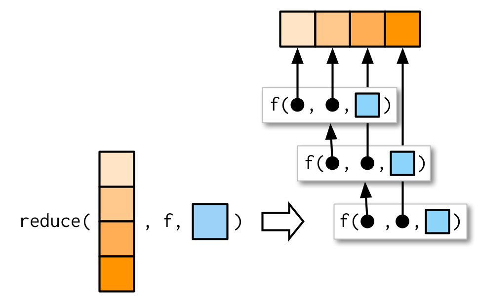

### 1.5.2 Accumulate

```r
l
```

```
## [[1]]
##  [1]  2  4 10  5  1  2  7  1  7  6  8  2  5  9  1
##
## [[2]]
##  [1]  2  8  2  8  2  2  7  7  4  4  4 10  3  2  6
##
## [[3]]
##  [1]  4  6  5 10  2  3  5 10  6  6  8  6  8  4  3
##
## [[4]]
##  [1]  1  2  3  6  8 10  9 10  9 10  9  8  1  1  5
```

```r
accumulate(l,intersect)
```

```
## [[1]]
##  [1]  2  4 10  5  1  2  7  1  7  6  8  2  5  9  1
##
## [[2]]
## [1]  2  4 10  7  6  8
##
## [[3]]
## [1]  2  4 10  6  8
##
## [[4]]
## [1]  2 10  6  8
```

```r
accumulate(1:10,sum)
```

```
##  [1]  1  3  6 10 15 21 28 36 45 55
```

```r
accumulate(1:10,mean)
```

```
##  [1] 1 1 1 1 1 1 1 1 1 1
```

### 1.5.3 Output types

### 1.5.4 Multiple inputs

### 1.5.5 Map-reduce

您可能听说过 `map-reduce`，它为Hadoop这样的技术提供动力。现在您可以看到底层的想法是多么简单和强大: map-reduce是一个结合了reduce的map。大数据的不同之处在于，数据分散在多台计算机上。每台计算机对其拥有的数据执行映射，然后将结果发送回协调器，协调器将单个结果还原为单个结果。

作为一个简单的例子，想象一下计算一个非常大的向量的平均值，这个向量如此之大，以至于必须在多台计算机上进行分割。你可以要求每台计算机计算和和长度，然后返回给协调器，协调器通过总和除以总长度来计算总体平均值。

## 1.6 Predicate functionals

**谓词**是一个返回单个TRUE或FALSE的函数，如 `is.character()`、 `is.null()`或 `all()` ，如果谓词返回TRUE，我们说谓词匹配向量。

- `some(.x, .p)` returns TRUE if any element matches; `every(.x, .p)` returns TRUE if all elements match.
- `detect(.x, .p)` returns the value of the first match; `detect_index(.x, .p)` returns the location of the first match.
- `keep(.x, .p)` keeps all matching elements; `discard(.x, .p)` drops all matching elements.

```r
df <- data.frame(x = 1:3, y = c("a", "b", "c"))
df
```

| x | y |
| --- | --- |
| 1 | a |
| 2 | b |
| 3 | c |

```r
detect(df,is.numeric)
```

```
## [1] 1 2 3
```

```r
detect_index(df, is.factor)
```

```
## [1] 0
```

```r
str(keep(df, is.factor))
```

```
## 'data.frame':    3 obs. of  0 variables
```

```r
str(discard(df, is.factor))
```

```
## 'data.frame':    3 obs. of  2 variables:
##  $ x: int  1 2 3
##  $ y: chr  "a" "b" "c"
```

```r
df <- data.frame(
  num1 = c(0, 10, 20),
  num2 = c(5, 6, 7),
  chr1 = c("a", "b", "c"),
  stringsAsFactors = FALSE
)
df
```

| num1 | num2 | chr1 |
| --- | --- | --- |
| 0 | 5 | a |
| 10 | 6 | b |
| 20 | 7 | c |

```r
map_if(df,is.numeric,mean)
```

```
## $num1
## [1] 10
##
## $num2
## [1] 6
##
## $chr1
## [1] "a" "b" "c"
```

```r
df %>%
  select(where(is.numeric)) %>%
  map(mean) %>%
  bind_rows()
```

| num1 | num2 |
| --- | --- |
| 10 | 6 |

```r
df %>%
  select(where(is.numeric)) %>%
  map(mean) %>%
  bind_cols()
```

| num1 | num2 |
| --- | --- |
| 10 | 6 |

```r
modify_if(df, is.numeric, mean)
```

| num1 | num2 | chr1 |
| --- | --- | --- |
| 10 | 6 | a |
| 10 | 6 | b |
| 10 | 6 | c |

**练习**

## 1.7 Base functionals

为了完成本章，我在这里提供了一些重要的基础函数，这些函数不是`map`、`reduce`或`谓词族`的成员，因此在purrr中没有等价的基础泛函。这并不是说它们不重要，但它们更多的是一种数学或统计的味道，而且它们在数据分析中通常不那么有用。

### 1.7.1 矩阵和数组

`Map()`和`friends`专门研究一维向量。`Apply()`专门研究二维向量和更高向量，即**矩阵和数组**。可以将`apply()`看作是通过将每一行或每一列折叠为单个值来总结矩阵或数组的操作。它有四个论点:

- X, the matrix or array to summarise.
- MARGIN, an integer vector giving the dimensions to summarise over, 1 = rows, 2 = columns, etc. (The argument name comes from thinking about the margins of a joint distribution.) -FUN, a summary function. -… other arguments passed on to FUN.

```r
a2d <- matrix(1:20, nrow = 5)
a2d
```

```
##      [,1] [,2] [,3] [,4]
## [1,]    1    6   11   16
## [2,]    2    7   12   17
## [3,]    3    8   13   18
## [4,]    4    9   14   19
## [5,]    5   10   15   20
```

```r
apply(a2d,1,mean)
```

```
## [1]  8.5  9.5 10.5 11.5 12.5
```

```r
apply(a2d,2,mean)
```

```
## [1]  3  8 13 18
```

```r
a2d <- matrix(1:20, nrow = 5) %>% as_tibble()
a2d %>% colMeans()
```

```
## V1 V2 V3 V4
##  3  8 13 18
```

```r
map(a2d,mean) %>% bind_rows()
```

| V1 | V2 | V3 | V4 |
| --- | --- | --- | --- |
| 3 | 8 | 13 | 18 |

因此，R最大的好处就在于灵活，可以通过很多方法实现自己的想法，也正是这种灵活性，在运用R的时候更加小心，要不很容易出错误。

- 与`base::sapply()`类似，您无法控制输出类型;它将自动简化为列表、矩阵或向量。但是，通常将`apply()`与数值数组和数值摘要函数一起使用，因此遇到问题的可能性比`sapply()`小。
- `Apply()`也不是幂等的，因为如果摘要函数是标识运算符，那么输出并不总是与输入相同。

```r
a1 <- apply(a2d, 1, identity)
identical(a2d, a1)
```

```
## [1] FALSE
```

```r
a2 <- apply(a2d, 2, identity)
identical(a2d, a2)
```

```
## [1] FALSE
```

- `禁止对数据帧使用apply()`。**它总是将其强制转换为矩阵**，如果数据帧包含数字以外的内容，则会导致不希望看到的结果。

```r
df <- data.frame(x = 1:3, y = c("a", "b", "c"))
apply(df, 2, mean)
```

```
##  x  y
## NA NA
```

### 1.7.2 Mathematical concerns

**函数**在数学中很常见。**极限**、**最大值**、根(f(x) = 0的点集)和**定积分**都是泛函:给定一个函数，它们返回一个数字(或数字向量)。乍一看，这些函数似乎不符合消除循环的主题，但如果你深入挖掘，你会发现它们都是使用一个涉及迭代的算法来实现的。

- `integrate()` finds the area under the curve defined by f()
- `uniroot()` finds where f() hits zero
- `optimise()` finds the location of the lowest (or highest) value of f()

```r
integrate(sin,0,pi)
```

```
## 2 with absolute error < 2.2e-14
```

```r
uniroot(sin, pi * c(1 / 2, 3 / 2))
```

```
## $root
## [1] 3.141593
##
## $f.root
## [1] 1.224606e-16
##
## $iter
## [1] 2
##
## $init.it
## [1] NA
##
## $estim.prec
## [1] 0.00006103516
```

```r
optimise(sin, c(0, 2 * pi))
```

```
## $minimum
## [1] 4.712391
##
## $objective
## [1] -1
```

```r
optimise(sin, c(0, pi), maximum = TRUE)
```

```
## $maximum
## [1] 1.570796
##
## $objective
## [1] 1
```

**练习**

## 1.8 [本章答案](https://advanced-r-solutions.rbind.io/functionals.html#map-variants)

```r
library(purrr)
library(tibble)
```

```r
trials <- map(1:100, ~ t.test(rpois(10, 10), rpois(10, 7)))
trials_df <- tibble(p_value = map_dbl(trials, "p.value"))
trials_df
```

| p_value |
| --- |
| 0.93648752180 |
| 0.00260942792 |
| 0.00001538076 |
| 0.00017126079 |
| 0.02343459145 |
| 0.05415340208 |
| 0.00008997103 |
| 0.25449863652 |
| 0.03158662405 |
| 0.55224450177 |

[output cut: 90 more lines]

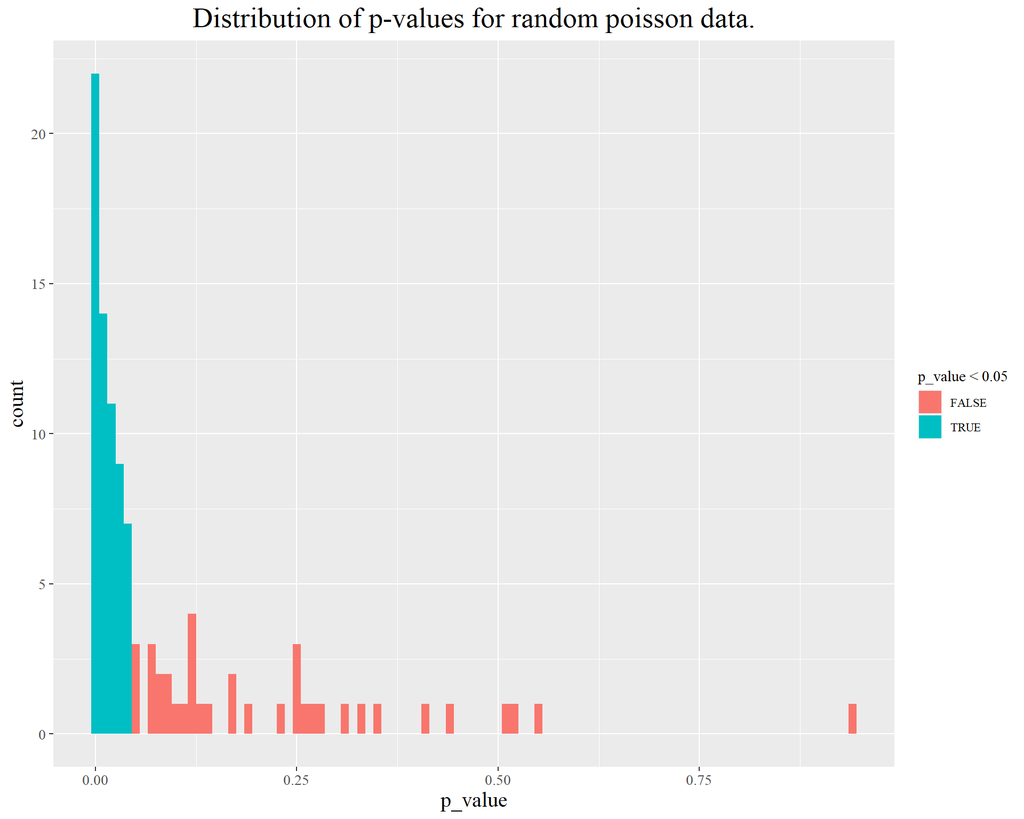

```r
trials_df %>%
  ggplot(aes(x = p_value,fill = p_value < 0.05)) +
  geom_histogram(binwidth = 0.01) +
  ggtitle("Distribution of p-values for random poisson data.") +
  mytheme
```

Q: The following code uses a `map` nested inside another map to apply a function to every element of a nested list. Why does it fail, and what do you need to do to make it work?

```r
x <- list(
  list(1, c(3, 9)),
  list(c(3, 6), 7, c(4, 7, 6))
)

triple <- function(x) x * 3
map(x, map, .f = triple)
```

```
## Error in .f(.x[[i]], ...): 参数没有用(function (.x, .f, ...)
## {
##     .f <- as_mapper(.f, ...)
##     .Call(map_impl, environment(), ".x", ".f", "list")
## })
```

```r
map(x[[1]],triple)
```

```
## [[1]]
## [1] 3
##
## [[2]]
## [1]  9 27
```

```r
map(x[[2]],triple)
```

```
## [[1]]
## [1]  9 18
##
## [[2]]
## [1] 21
##
## [[3]]
## [1] 12 21 18
```

```r
map(seq_along(x),function(i){
  map(x[[i]],triple)
})
```

```
## [[1]]
## [[1]][[1]]
## [1] 3
##
## [[1]][[2]]
## [1]  9 27
##
##
## [[2]]
## [[2]][[1]]
## [1]  9 18
##
## [[2]][[2]]
## [1] 21
##
## [[2]][[3]]
## [1] 12 21 18
```

A: This function call fails, because `triple()` is specified as the `.f argument` and consequently belongs to the outer `map()`. The unnamed argument `map` is treated as an argument of triple(), which causes the error.

There are a number of ways we could resolve the problem. I don’t think there’s much to choose between them for this simple example, but it’s good to know your options for more complicated cases.

Q: Use `map()` to fit linear models to the mtcars using the formulas stored in this list:

```r
formulas <- list(
  mpg ~ disp,
  mpg ~ I(1 / disp),
  mpg ~ disp + wt,
  mpg ~ I(1 / disp) + wt
)
map(formulas,~lm(formula = .x,data = mtcars)) %>%
  map(summary) %>%
  map("r.squared")
```

```
## [[1]]
## [1] 0.7183433
##
## [[2]]
## [1] 0.8596865
##
## [[3]]
## [1] 0.7809306
##
## [[4]]
## [1] 0.8838038
```

```r
bootstrap <- function(df) {
  df[sample(nrow(df), replace = TRUE), , drop = FALSE]
}

bootstraps <- map(1:10, ~ bootstrap(mtcars))
bootstraps[[1]]
```

|  | mpg | cyl | disp | hp | drat | wt | qsec | vs | am | gear | carb |
| --- | --- | --- | --- | --- | --- | --- | --- | --- | --- | --- | --- |
| Fiat X1-9 | 27.3 | 4 | 79.0 | 66 | 4.08 | 1.935 | 18.90 | 1 | 1 | 4 | 1 |
| Chrysler Imperial | 14.7 | 8 | 440.0 | 230 | 3.23 | 5.345 | 17.42 | 0 | 0 | 3 | 4 |
| Chrysler Imperial.1 | 14.7 | 8 | 440.0 | 230 | 3.23 | 5.345 | 17.42 | 0 | 0 | 3 | 4 |
| Volvo 142E | 21.4 | 4 | 121.0 | 109 | 4.11 | 2.780 | 18.60 | 1 | 1 | 4 | 2 |
| Pontiac Firebird | 19.2 | 8 | 400.0 | 175 | 3.08 | 3.845 | 17.05 | 0 | 0 | 3 | 2 |
| Maserati Bora | 15.0 | 8 | 301.0 | 335 | 3.54 | 3.570 | 14.60 | 0 | 1 | 5 | 8 |
| Valiant | 18.1 | 6 | 225.0 | 105 | 2.76 | 3.460 | 20.22 | 1 | 0 | 3 | 1 |
| Cadillac Fleetwood | 10.4 | 8 | 472.0 | 205 | 2.93 | 5.250 | 17.98 | 0 | 0 | 3 | 4 |
| Merc 450SL | 17.3 | 8 | 275.8 | 180 | 3.07 | 3.730 | 17.60 | 0 | 0 | 3 | 3 |
| Hornet 4 Drive | 21.4 | 6 | 258.0 | 110 | 3.08 | 3.215 | 19.44 | 1 | 0 | 3 | 1 |

[output cut: 22 more lines]

```r
bootstraps %>%
  map(~lm(formula = mpg ~ disp, data = .x)) %>%
  map(summary) %>%
  map_dbl("r.squared")
```

```
##  [1] 0.7294467 0.5793415 0.7838698 0.6502672 0.7099633 0.7343832 0.7842610
##  [8] 0.7798887 0.7068993 0.5828845
```

我们从**拟合模型**开始。然后，我们计算汇总并提取$R^2$值。对于最后一次调用，我们使用map_dbl，它提供了方便的输出。

Q: Explain the results of `modify(mtcars, 1)`.

答: `modify()`基于`map()` ，在这种情况下，将使用提取器接口。它提取 `mtcars` 中每个列的第一个元素。`Modify()`总是返回与其输入相同的结构: 在这种情况下，它强制第一行被回收32次。(内部修改()用法。X [] <-map (.X，.F，…) for assignment.)

```r
mtcars %>% modify(1)
```

|  | mpg | cyl | disp | hp | drat | wt | qsec | vs | am | gear | carb |
| --- | --- | --- | --- | --- | --- | --- | --- | --- | --- | --- | --- |
| Mazda RX4 | 21 | 6 | 160 | 110 | 3.9 | 2.62 | 16.46 | 0 | 1 | 4 | 4 |
| Mazda RX4 Wag | 21 | 6 | 160 | 110 | 3.9 | 2.62 | 16.46 | 0 | 1 | 4 | 4 |
| Datsun 710 | 21 | 6 | 160 | 110 | 3.9 | 2.62 | 16.46 | 0 | 1 | 4 | 4 |
| Hornet 4 Drive | 21 | 6 | 160 | 110 | 3.9 | 2.62 | 16.46 | 0 | 1 | 4 | 4 |
| Hornet Sportabout | 21 | 6 | 160 | 110 | 3.9 | 2.62 | 16.46 | 0 | 1 | 4 | 4 |
| Valiant | 21 | 6 | 160 | 110 | 3.9 | 2.62 | 16.46 | 0 | 1 | 4 | 4 |
| Duster 360 | 21 | 6 | 160 | 110 | 3.9 | 2.62 | 16.46 | 0 | 1 | 4 | 4 |
| Merc 240D | 21 | 6 | 160 | 110 | 3.9 | 2.62 | 16.46 | 0 | 1 | 4 | 4 |
| Merc 230 | 21 | 6 | 160 | 110 | 3.9 | 2.62 | 16.46 | 0 | 1 | 4 | 4 |
| Merc 280 | 21 | 6 | 160 | 110 | 3.9 | 2.62 | 16.46 | 0 | 1 | 4 | 4 |

[output cut: 22 more lines]

```r
map(mtcars,1)
```

```
## $mpg
## [1] 21
##
## $cyl
## [1] 6
##
## $disp
## [1] 160
##
## $hp
## [1] 110
##
## $drat
## [1] 3.9
##
## $wt
## [1] 2.62
##
## $qsec
## [1] 16.46
##
## $vs
## [1] 0
##
## $am
## [1] 1
##
## $gear
## [1] 4
##
## $carb
## [1] 4
```

```r
cyls <- split(mtcars, mtcars$cyl)
cyls[[1]]
paths <- file.path("data/", paste0("cyl-", names(cyls), ".csv"))
paths
walk2(cyls, paths, ~ write.csv(.x, .y))
```

Q: Explain how the following code transforms a data frame using functions stored in a list.

```r
trans <- list(
  disp = function(x) x * 0.0163871,
  am = function(x) factor(x, labels = c("auto", "manual"))
)

vars <- names(trans)
mtcars[vars] <- map2(trans, mtcars[vars], function(f, var) f(var))
```

问：`write.csv（）`返回什么？即如果将其与`map2（）`而不是`walk2（）`一起使用会发生什么？

```r
map2(数据，路径，write.csv)
```

```r
paths_iris <- str_c("data/","iris_",levels(iris$Species),".csv")
paths_iris
```

```
## [1] "data/iris_setosa.csv"     "data/iris_versicolor.csv"
## [3] "data/iris_virginica.csv"
```

```r
split(iris,iris$Species) %>%
  map2(paths_iris,write.csv)
```

```
## Error in file(file, ifelse(append, "a", "w")): 无法打开链结
```

```r
split(iris,iris$Species) %>%
  walk2(paths_iris,write.csv)
```

```
## Error in file(file, ifelse(append, "a", "w")): 无法打开链结
```

问：为什么`is.na（）`不是谓词函数？哪个基R函数最接近is.na（）的谓词版本？

答：`is.na（）`不是谓词函数，**因为它返回与输入长度相同的逻辑向量**，而不是单个TRUE或FALSE。

```r
is.data.frame(iris)
```

```
## [1] TRUE
```

```r
is.na(1:10)
```

```
##  [1] FALSE FALSE FALSE FALSE FALSE FALSE FALSE FALSE FALSE FALSE
```

Q: The function below scales a vector so it falls in the range [0, 1]. How would you apply it to every column of a data frame? How would you apply it to every numeric column in a data frame?

```r
scale01 <- function(x) {
  rng <- range(x, na.rm = TRUE)
  (x - rng[1]) / (rng[2] - rng[1])
}
```

```r
scale01 %>% map_if(iris,is.numeric,.) %>% bind_rows()
```

| Sepal.Length | Sepal.Width | Petal.Length | Petal.Width | Species |
| --- | --- | --- | --- | --- |
| 0.22222222 | 0.62500000 | 0.06779661 | 0.04166667 | setosa |
| 0.16666667 | 0.41666667 | 0.06779661 | 0.04166667 | setosa |
| 0.11111111 | 0.50000000 | 0.05084746 | 0.04166667 | setosa |
| 0.08333333 | 0.45833333 | 0.08474576 | 0.04166667 | setosa |
| 0.19444444 | 0.66666667 | 0.06779661 | 0.04166667 | setosa |
| 0.30555556 | 0.79166667 | 0.11864407 | 0.12500000 | setosa |
| 0.08333333 | 0.58333333 | 0.06779661 | 0.08333333 | setosa |
| 0.19444444 | 0.58333333 | 0.08474576 | 0.04166667 | setosa |
| 0.02777778 | 0.37500000 | 0.06779661 | 0.04166667 | setosa |
| 0.16666667 | 0.45833333 | 0.08474576 | 0.00000000 | setosa |

[output cut: 140 more lines]

```r
modify_if(iris,is.numeric,scale01) %>% as_tibble()
```

| Sepal.Length | Sepal.Width | Petal.Length | Petal.Width | Species |
| --- | --- | --- | --- | --- |
| 0.22222222 | 0.62500000 | 0.06779661 | 0.04166667 | setosa |
| 0.16666667 | 0.41666667 | 0.06779661 | 0.04166667 | setosa |
| 0.11111111 | 0.50000000 | 0.05084746 | 0.04166667 | setosa |
| 0.08333333 | 0.45833333 | 0.08474576 | 0.04166667 | setosa |
| 0.19444444 | 0.66666667 | 0.06779661 | 0.04166667 | setosa |
| 0.30555556 | 0.79166667 | 0.11864407 | 0.12500000 | setosa |
| 0.08333333 | 0.58333333 | 0.06779661 | 0.08333333 | setosa |
| 0.19444444 | 0.58333333 | 0.08474576 | 0.04166667 | setosa |
| 0.02777778 | 0.37500000 | 0.06779661 | 0.04166667 | setosa |
| 0.16666667 | 0.45833333 | 0.08474576 | 0.00000000 | setosa |

[output cut: 140 more lines]

# 2 函数工厂

## 2.1 介绍

**函数工厂**是一个创建函数的函数。这里有一个非常简单的例子: 我们使用一个函数工厂(`power1()`)生成两个子函数(`square ()`和 `cube ()`) :

```r
power1 <- function(exp){
  function(x){
    x^exp
  }
}
square <- power1(2)
cube <- power1(3)
```

```r
square(10)
```

```
## [1] 100
```

```r
cube(10)
```

```
## [1] 1000
```

我将其命名为`square（）`和`cube（）`制造函数，但这只是为了简化与其他人之间的交流而使用的术语：从R的角度看，它们与以任何其他方式创建的函数没有什么不同。

## 2.2 函数工厂基础

### 2.2.1 Environments

```r
square
```

```
## function(x){
##     x^exp
##   }
## <environment: 0x000000002b175ab0>
```

```r
cube
```

```
## function(x){
##     x^exp
##   }
## <bytecode: 0x000000002b38b868>
## <environment: 0x000000002b1ea930>
```

很明显x来自哪里，但是**R如何找到与exp相关的值？**由于主体是相同的，因此简单地打印制造的功能并不能显示出来。封闭环境的内容是重要因素。通过使用`rlang::env_print（）`，我们可以获得更多的见识。这说明我们有两个不同的环境（每个环境最初都是power1（）的执行环境）。这些环境具有相同的父级，即全局环境power1（）的封闭环境。

```r
library(rlang)
env_print(square)
```

```
## <environment: 000000002B175AB0>
## parent: <environment: global>
## bindings:
##  * exp: <dbl>
```

```r
env_print(cube)
```

```
## <environment: 000000002B1EA930>
## parent: <environment: global>
## bindings:
##  * exp: <dbl>
```

`env_print（）`向我们展示了这两种环境都**对exp有绑定**，但是我们希望看到它的value。我们可以通过首先获取函数的环境，然后提取值来做到这一点：

```r
fn_env(square)$exp
```

```
## [1] 2
```

```r
fn_env(cube)$exp
```

```
## [1] 3
```

这就是使制造的函数的行为彼此不同的原因：封闭环境中的名称绑定到不同的值。

### 2.2.2 Diagram conventions

```r
x <- 2
square <- power1(x)
x <- 3
```

## 2.3 Graphical factories

我们将从 ggplot2中的一些例子开始探索有用的函数工厂。

### 2.3.1 Labelling

```r
library(scales)
y <- c(12345,123456,1234567)
scales::comma_format()(y)
```

```
## [1] "12,345"    "123,456"   "1,234,567"
```

```r
scales::number_format(scale = 0.001,suffix = "K")(y)
```

```
## [1] "12K"    "123K"   "1 235K"
```

```r
iris %>%
  ggplot(aes(Sepal.Length,Sepal.Width*100000)) +
  geom_point() +
  scale_x_continuous(limits = c(4,8)) +
  labs(x = NULL,y = NULL) +
  mytheme -> p1
```

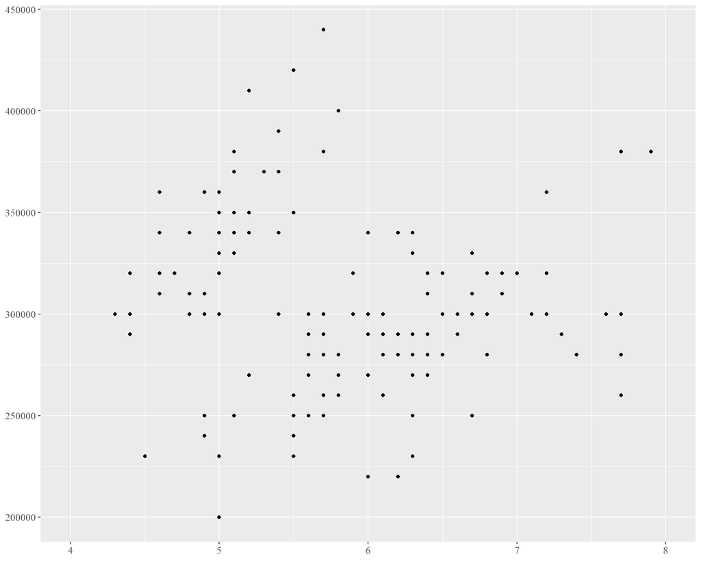

```r
p1
```

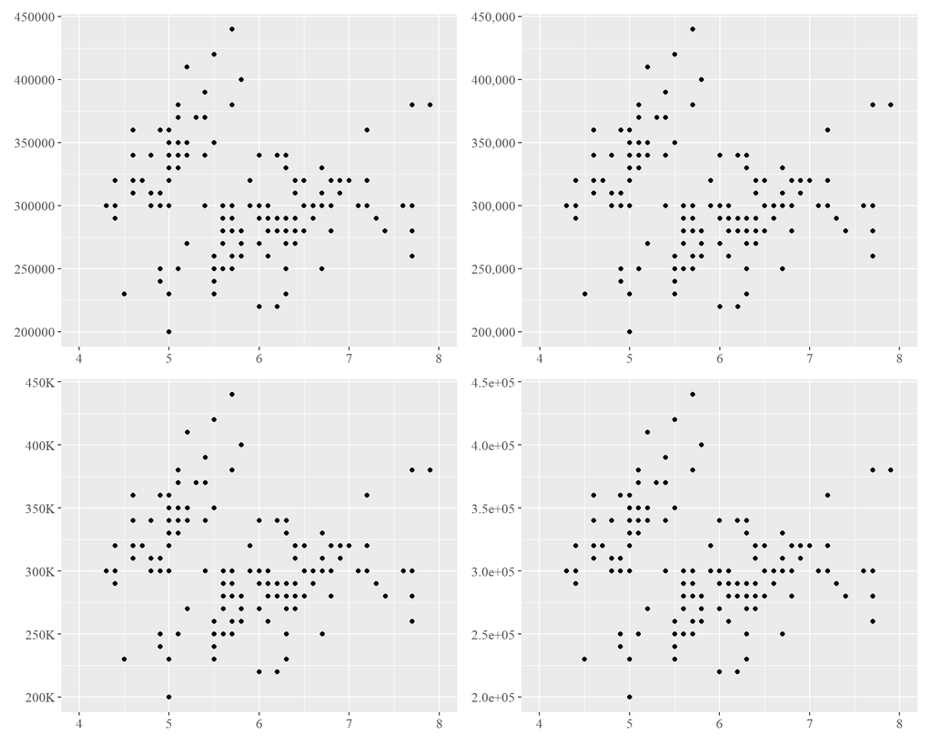

```r
library(patchwork)
p1 +
  scale_y_continuous(labels = comma_format()) -> p2

p1 +
  scale_y_continuous(labels = number_format(scale = 0.001,
                                            suffix = "K")) -> p3

p1 + scale_y_continuous(labels = scientific_format()) -> p4

(p1 + p2)/(p3 + p4)
```

换句话说，主接口是一个函数工厂。乍一看，这似乎增加了额外的复杂性，而收益甚微。但是它能与 ggplot2的 scales 进行良好的交互，因为它们接受 label 参数中的函数

### 2.3.2 Histogram bins

## 2.4 Statistical factories

### 2.4.1 Box-Cox transformation

### 2.4.2 Bootstrap generators

### 2.4.3 Maximum likelihood estimation

## 2.5 Function factories + functionals

## 2.6 [本章答案](https://advanced-r-solutions.rbind.io/function-factories.html)

Q: Why might you formulate the Box-Cox transformation like this?

```r
boxcox3 <- function(x) {
  function(lambda) {
    if (lambda == 0) {
      log(x)
    } else {
      (x ^ lambda - 1) / lambda
    }
  }
}
boxcox3(1:10) -> boxcox31
boxcox31 %>% env_print()
```

```
## <environment: 000000002A8A6178>
## parent: <environment: global>
## bindings:
##  * x: <lazy>
```

```r
fn_env(boxcox31)$x
```

```
##  [1]  1  2  3  4  5  6  7  8  9 10
```

```r
boxcox31(0)
```

```
##  [1] 0.0000000 0.6931472 1.0986123 1.3862944 1.6094379 1.7917595 1.9459101
##  [8] 2.0794415 2.1972246 2.3025851
```

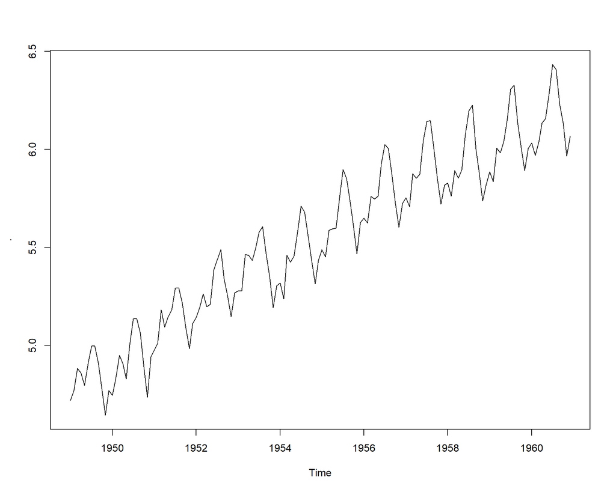

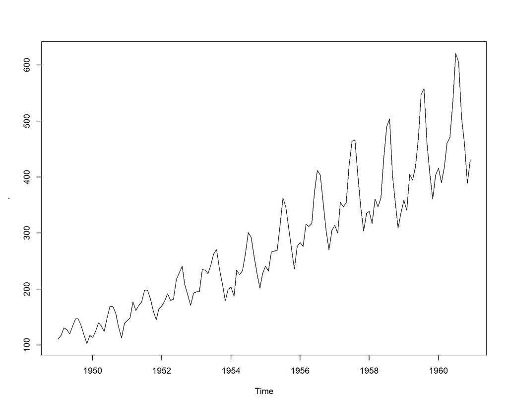

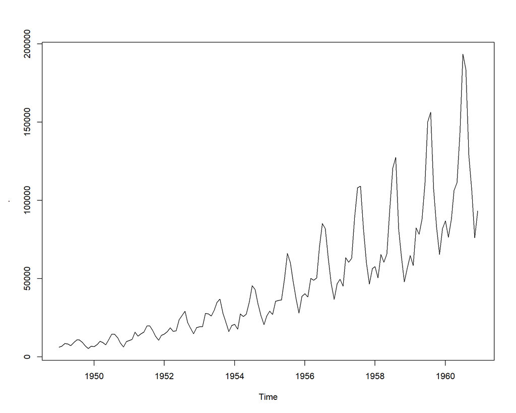

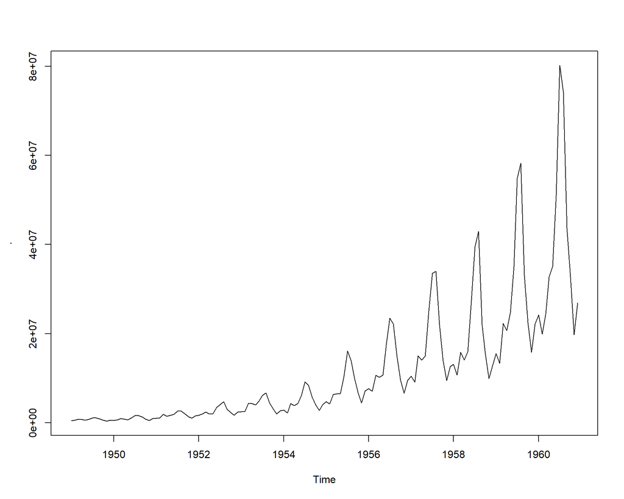

```r
boxcox_airpassengers <- boxcox3(AirPassengers)
boxcox_airpassengers(0) %>% plot()

boxcox_airpassengers(1) %>% plot()

boxcox_airpassengers(2) %>% plot()

boxcox_airpassengers(3) %>% plot()
```

# 3 Function operators

## 3.1 介绍

```r
library(purrr)
library(memoise)
```

## 3.2 Existing function operators

有两个非常有用的函数运算符，既可以帮助您解决常见的重复出现的问题，又可以使您了解函数运算符可以做什么：`purrr::safely（）`和`memoise::memoise（）`。

### 3.2.1 Capturing errors with `purrr::safely()`

for循环的优点之一是，如果其中一个迭代失败，您仍然可以访问直到失败为止的所有结果：

```r
x <- list(
  c(0.512, 0.165, 0.717),
  c(0.064, 0.781, 0.427),
  c(0.890, 0.785, 0.495),
  "oops"
)
out <- vector(mode = "double",length = length(x))
for (i in seq_along(x)) {
 out[[i]] <-  sum(x[[i]])
}
```

```
## Error in sum(x[[i]]): 'type'(character)参数不对
```

```r
out
```

```
## [1] 1.394 1.272 2.170 0.000
```

如果对函数执行相同的操作，则不会得到任何输出，从而很难找出问题所在：

```r
map(x,sum)
```

```
## Error in .Primitive("sum")(..., na.rm = na.rm): 'type'(character)参数不对
```

`purrr::safely（）`提供了一个工具来解决此问题。`safety（）`是函数运算符，用于转换函数以将错误转换为数据。

像所有函数运算符一样，`safely（）`接受一个函数并返回一个包装好的函数，我们可以像往常一样调用该函数：

```r
safe_sum <- safely(sum)
safe_sum
```

```
## function (...)
## capture_error(.f(...), otherwise, quiet)
## <bytecode: 0x00000000212526f8>
## <environment: 0x0000000021252c00>
```

```r
safe_sum(x[[1]])
```

```
## $result
## [1] 1.394
##
## $error
## NULL
```

```r
map(x,safe_sum)
```

```
## [[1]]
## [[1]]$result
## [1] 1.394
##
## [[1]]$error
## NULL
##
##
## [[2]]
## [[2]]$result
## [1] 1.272
##
## [[2]]$error
## NULL
##
##
## [[3]]
## [[3]]$result
## [1] 2.17
##
## [[3]]$error
## NULL
##
##
## [[4]]
## [[4]]$result
## NULL
##
## [[4]]$error
## <simpleError in .Primitive("sum")(..., na.rm = na.rm): 'type'(character)参数不对>
```

您可以看到，由`safely（）`转换的函数始终返回**包含两个元素的列表**，即结果和错误。如果函数成功运行，则错误为NULL，并且result包含结果；否则为false。 如果函数失败，则结果为NULL，并且error包含错误。

```r
map(x,safely(sum)) %>% map("result")
```

```
## [[1]]
## [1] 1.394
##
## [[2]]
## [1] 1.272
##
## [[3]]
## [1] 2.17
##
## [[4]]
## NULL
```

```r
map(x,safely(sum)) %>% str()
```

```
## List of 4
##  $ :List of 2
##   ..$ result: num 1.39
##   ..$ error : NULL
##  $ :List of 2
##   ..$ result: num 1.27
##   ..$ error : NULL
##  $ :List of 2
##   ..$ result: num 2.17
##   ..$ error : NULL
##  $ :List of 2
##   ..$ result: NULL
##   ..$ error :List of 2
##   .. ..$ message: chr "'type'(character)参数不对"
##   .. ..$ call   : language .Primitive("sum")(..., na.rm = na.rm)
##   .. ..- attr(*, "class")= chr [1:3] "simpleError" "error" "condition"
```

输出形式略有不便，因为我们有四个列表，每个列表都是一个包含结果和错误的列表。通过使用`purrr::transpose（）`将输出“由内向外”，可以使输出更易于使用，从而获得结果列表和错误列表：

```r
transpose(map(x,safely(sum))) -> out
out
```

```
## $result
## $result[[1]]
## [1] 1.394
##
## $result[[2]]
## [1] 1.272
##
## $result[[3]]
## [1] 2.17
##
## $result[[4]]
## NULL
##
##
## $error
## $error[[1]]
## NULL
##
## $error[[2]]
## NULL
##
## $error[[3]]
## NULL
##
## $error[[4]]
## <simpleError in .Primitive("sum")(..., na.rm = na.rm): 'type'(character)参数不对>
```

```r
out$result
```

```
## [[1]]
## [1] 1.394
##
## [[2]]
## [1] 1.272
##
## [[3]]
## [1] 2.17
##
## [[4]]
## NULL
```

您可以在许多不同的情况下使用相同的技术。例如，假设您正在将**广义线性模型（GLM）**拟合到数据框列表中。GLM有时会由于优化问题而失败，但是您仍然希望能够尝试拟合所有模型，然后稍后回顾失败的模型：

```r
fit_models <- function(df){
  glm(y ~ x1 + x2 + x3,data = df)
}
datasets <- list(datasets::ability.cov,
                 datasets::attenu,
                 datasets::cars)
map(datasets,fit_models)
```

```
## Error in eval(predvars, data, env): 找不到对象'x1'
```

```r
map(datasets,safely(fit_models)) %>% transpose() -> models
map(models$error,is.null)
```

```
## [[1]]
## [1] FALSE
##
## [[2]]
## [1] FALSE
##
## [[3]]
## [1] FALSE
```

```r
models$result
```

我认为这是组合**函数**和**函数运算符**的强大功能的一个很好的例子：`safely（）`使您可以简洁地表达解决常见数据分析问题所需的内容。

purrr带有其他三个类似的函数运算符：

- `possibly()`: returns a default value when there’s an error. It provides no way to tell if an error occured or not, so it’s best reserved for cases when there’s some obvious sentinel value (like NA).
- `quietly()`: turns output, messages, and warning side-effects into output, message, and warning components of the output.
- `auto_browser()`: automatically executes `browser()` inside the function when there’s an error.

### 3.2.2 Caching computations with `memoise::memoise()`

另一个方便的函数运算符是`memoise::memoise（）`。它表示一个函数，意味着该函数将记住先前的输入并返回缓存的结果。记忆化是经典计算机科学在内存与速度之间进行权衡的一个示例。备忘的功能可以运行得更快，但是由于它存储了所有先前的输入和输出，因此使用了更多的内存。

```r
slow_function <- function(x){
  Sys.sleep(3)
  x * 10 * runif(1)
}
slow_function(10)
```

```
## [1] 23.21857
```

```r
library(tictoc)
tic()
slow_function(10)
```

```
## [1] 48.73666
```

```r
toc()
```

```
## 3.02 sec elapsed
```

当我们记住该函数时，使用新的参数调用它会很慢。但是，当我们使用在瞬时之前看到的参数来调用它时：它将检索计算的前一个值。

```r
fast_function <- memoise::memoise(slow_function)
tic()
fast_function(10)
```

```
## [1] 4.923656
```

```r
toc()
```

```
## 3 sec elapsed
```

```r
tic()
fast_function(10)
```

```
## [1] 4.923656
```

```r
toc()
```

```
## 0.03 sec elapsed
```

```r
fib <- function(n) {
  if (n < 2) return(1)
  fib(n - 2) + fib(n - 1)
}
tic()
fib(30)
```

```
## [1] 1346269
```

```r
toc()
```

```
## 1.67 sec elapsed
```

```r
fib2 <- memoise(fib)
tic()
fib2(30)
```

```
## [1] 1346269
```

```r
toc()
```

```
## 1.64 sec elapsed
```

```r
tic()
fib2(30)
```

```
## [1] 1346269
```

```r
toc()
```

```
## 0.03 sec elapsed
```

记住函数之前请仔细考虑。如果函数不是纯函数，即**输出不仅仅取决于输入**，您将得到令人误解和令人困惑的结果。我在devtools中创建了一个细微的错误，因为我记下了`available.packages（）`的结果，这相当慢，因为它必须从CRAN下载大文件。可用的软件包不会经常更改，但是如果您的R进程已经运行了几天，那么更改可能变得很重要，并且由于该问题仅出现在长时间运行的R进程中，因此该错误非常痛苦找。

**练习**

```r
x <- list(x = 1:10,
          y = 1:10,
          "oob")
map(x,sum)
```

```
## Error in .Primitive("sum")(..., na.rm = na.rm): 'type'(character)参数不对
```

```r
map(x,safely(sum))
```

```
## $x
## $x$result
## [1] 55
##
## $x$error
## NULL
##
##
## $y
## $y$result
## [1] 55
##
## $y$error
## NULL
##
##
## [[3]]
## [[3]]$result
## NULL
##
## [[3]]$error
## <simpleError in .Primitive("sum")(..., na.rm = na.rm): 'type'(character)参数不对>
```

```r
map(x,safely(sum)) %>% map("result")
```

```
## $x
## [1] 55
##
## $y
## [1] 55
##
## [[3]]
## NULL
```

```r
map(x,safely(sum)) %>% transpose() %>% map("x")
```

```
## $result
## [1] 55
##
## $error
## NULL
```

## 3.3 Case study: `Creating your own function operators`

`meomoise（）`和`safety（）`非常有用，但也很复杂。在本案例研究中，您将学习如何创建自己的简单函数运算符。假设您有一个命名的网址载体，并且想要将每个网址下载到磁盘。使用`walk2（）`和`file.download（）`非常简单：

```r
urls <- c(
  "adv-r" = "https://adv-r.hadley.nz",
  "r4ds" = "http://r4ds.had.co.nz/",
   "data-science-workflows" = "https://mdneuzerling.com/post/data-science-workflows/",
  "meta-rmarkdown" = "https://themockup.blog/posts/2020-07-25-meta-rmarkdown/",
  "advanced-r-solutions" = "https://advanced-r-solutions.rbind.io/function-operators.html"


  # and many many more
)
paths <- str_c("pdf/",names(urls),".html")
walk2(urls,paths,download.file)
```

```
## Error in .f(.x[[i]], .y[[i]], ...): 无法打开目的文件'pdf/adv-r.html'，原因是'No such file or directory'
```

**这种方法适用于少数几个URL**，但是随着向量变长，您可能希望添加更多功能：

- Add a small delay between each request to avoid hammering the server.
- Display a `.` every few URLs so that we know that the function is still working.

我认为此for循环次优，因为它交错了不同的问题：**暂停**，**显示进度**和**下载**。 这使代码更难阅读，在新情况下也更难重用组件。相反，让我们看看是否可以使用**函数运算符**提取暂停并显示进度并使它们可重用。

```r
for(i in seq_along(urls)) {
  Sys.sleep(0.1)
  if (i %% 10 == 0) cat(".")
  download.file(urls[[i]], paths[[i]])
}
```

```r
map(seq_along(urls),function(i){
  Sys.sleep(0.1)
  if(i %% 10 == 0){cat(".")}
  download.file(urls[[i]],paths[[i]])
})
```

```
## Error in download.file(urls[[i]], paths[[i]]): 无法打开目的文件'pdf/adv-r.html'，原因是'No such file or directory'
```

```r
walk2(urls,paths,download.file)
```

```
## Error in .f(.x[[i]], .y[[i]], ...): 无法打开目的文件'pdf/adv-r.html'，原因是'No such file or directory'
```

## 3.4 [本章答案](https://advanced-r-solutions.rbind.io/function-operators.html)

`safety（）`修改函数以返回包含元素“结果”和“错误”的列表。它的工作方式与`possible（）`类似，除了使用`as_mapper（）`外，`safely（）`还提供了else和quiet参数。但是，为了以一致的方式提供结果和错误，实现的`tryCatch（）`部分在两种情况下都返回具有相同结构的列表。在成功评估的情况下，“错误”等于NULL，在错误情况下，“结果”等于其他值，默认情况下为NULL。